# Lab 7 Heart Attack

Author

Antonio Gutierrez

Importing dependencies, data, and preprocessing.

```python
import pandas as pd
import numpy as np
from sklearn.pipeline import Pipeline
from sklearn.neighbors import KNeighborsRegressor, KNeighborsClassifier
from sklearn.tree import DecisionTreeRegressor, DecisionTreeClassifier
from sklearn.linear_model import LogisticRegression, LinearRegression
from sklearn.neighbors import NearestNeighbors
from sklearn.metrics import mean_squared_error, r2_score, accuracy_score, confusion_matrix, classification_report, make_scorer, roc_auc_score, precision_score, recall_score
from plotnine import *
from sklearn.preprocessing import OneHotEncoder, label_binarize, StandardScaler
from sklearn.compose import ColumnTransformer
from sklearn.model_selection import train_test_split
from sklearn.model_selection import cross_val_score
```

```python
knn = KNeighborsRegressor()
dt = DecisionTreeRegressor()
knn = KNeighborsRegressor()
dt = DecisionTreeRegressor()
lr = LinearRegression()
enc = OneHotEncoder()
lg = LogisticRegression()
```

```python
ha = pd.read_csv("/content/heart_attack.csv")
ha.head()
```

|  | age | sex | cp | trtbps | chol | restecg | thalach | output |
| --- | --- | --- | --- | --- | --- | --- | --- | --- |
| 0 | 63 | 1 | 3 | 145 | 233 | 0 | 150 | 1 |
| 1 | 37 | 1 | 2 | 130 | 250 | 1 | 187 | 1 |
| 2 | 56 | 1 | 1 | 120 | 236 | 1 | 178 | 1 |
| 3 | 57 | 0 | 0 | 120 | 354 | 1 | 163 | 1 |
| 4 | 57 | 1 | 0 | 140 | 192 | 1 | 148 | 1 |

Dummify Categorical Variables

```python
ct = ColumnTransformer(
    [
    ('dummify_cp', enc, ['cp']),
    ('dummify_sex', enc, ['sex']),
    ('dummify_rECG', enc, ['restecg'])],
    remainder = 'passthrough'
)
```

Splitting data

```python
X = ha.drop('output', axis = 1)
y = ha['output']
```

## Part One: Fitting Models

I found that including all the variables initally had the best result. Given that this is medical information, this makes sense because having more information is better and can be more useful in determining and predicting health issues. It is unlikely that you could have a better prediction or diagnosis with less information, especially since all of these variables are relevant. Given additional time, transformations to the data could have been made such as interaction variables to account for the relationships.

### Q1: KNN

```python
my_pipeline = Pipeline(
    [('dummify',ct), ('knc', KNeighborsClassifier(n_neighbors = 5))]
)
```

```python
my_pipeline.fit(X, y)
```

```
Pipeline(steps=[('dummify',
                 ColumnTransformer(remainder='passthrough',
                                   transformers=[('dummify_cp', OneHotEncoder(),
                                                  ['cp']),
                                                 ('dummify_sex',
                                                  OneHotEncoder(), ['sex']),
                                                 ('dummify_rECG',
                                                  OneHotEncoder(),
                                                  ['restecg'])])),
                ('knc', KNeighborsClassifier())])
```

```python
ypreds = my_pipeline.predict(X)
ypreds
```

```
array([1, 1, 1, 1, 0, 1, 1, 1, 1, 1, 0, 1, 1, 1, 1, 0, 1, 1, 1, 1, 0, 0,
       0, 1, 1, 1, 0, 1, 0, 1, 1, 1, 0, 0, 0, 1, 1, 0, 1, 1, 1, 1, 1, 1,
       1, 1, 1, 1, 0, 1, 1, 1, 1, 1, 1, 0, 1, 1, 1, 1, 1, 0, 0, 1, 1, 1,
       1, 1, 1, 1, 1, 1, 1, 1, 0, 1, 1, 0, 1, 1, 1, 0, 1, 1, 0, 1, 1, 0,
       1, 1, 1, 1, 1, 0, 1, 1, 1, 1, 1, 1, 1, 1, 1, 0, 1, 1, 1, 1, 1, 1,
       0, 1, 1, 1, 1, 1, 1, 0, 0, 0, 0, 1, 1, 1, 1, 1, 1, 1, 1, 1, 1, 1,
       1, 0, 1, 1, 0, 1, 1, 1, 1, 1, 1, 1, 1, 1, 0, 0, 1, 0, 0, 0, 0, 1,
       0, 0, 0, 0, 0, 0, 0, 0, 0, 0, 1, 0, 0, 1, 1, 0, 0, 0, 1, 1, 0, 1,
       0, 0, 0, 1, 0, 0, 0, 1, 0, 0, 1, 0, 0, 1, 1, 0, 0, 0, 0, 0, 1, 0,
       0, 0, 0, 0, 0, 0, 0, 1, 0, 0, 0, 0, 1, 1, 0, 0, 0, 0, 1, 0, 0, 0,
       1, 1, 0, 0, 0, 0, 0, 0, 0, 0, 1, 1, 0, 0, 0, 1, 1, 0, 0, 1, 0, 0,
       0, 1, 0, 0, 1, 1, 0, 0, 0, 0, 0, 0, 1, 0, 1, 0, 1, 0, 0, 0, 0, 0,
       0, 0, 0, 0, 0, 0, 0, 0, 1])
```

```python
accuracy = accuracy_score(y, ypreds)
accuracy
```

```
0.7728937728937729
```

```python
confusedmetric = confusion_matrix(y, ypreds)
confusedmetric
```

```
array([[ 95,  32],
       [ 30, 116]])
```

### Q2: Logistic Regression

```python
my_pipeline2 = Pipeline(
    [('dummify',ct), ('lg', LogisticRegression())]
)
```

```python
my_pipeline2.fit(X, y)
```

```
Pipeline(steps=[('dummify',
                 ColumnTransformer(remainder='passthrough',
                                   transformers=[('dummify_cp', OneHotEncoder(),
                                                  ['cp']),
                                                 ('dummify_sex',
                                                  OneHotEncoder(), ['sex']),
                                                 ('dummify_rECG',
                                                  OneHotEncoder(),
                                                  ['restecg'])])),
                ('lg', LogisticRegression())])
```

```python
ypreds2 = my_pipeline2.predict(X)
ypreds2
```

```
array([0, 1, 1, 1, 0, 1, 1, 1, 1, 0, 1, 1, 1, 1, 1, 1, 0, 1, 1, 0, 1, 1,
       1, 1, 1, 1, 0, 1, 0, 1, 1, 1, 1, 1, 1, 1, 0, 1, 1, 1, 1, 1, 1, 1,
       1, 0, 1, 1, 1, 1, 1, 1, 1, 1, 1, 1, 1, 1, 1, 1, 1, 1, 1, 1, 1, 0,
       1, 1, 1, 1, 1, 1, 1, 1, 1, 1, 1, 0, 0, 1, 1, 1, 0, 0, 0, 1, 1, 0,
       1, 1, 1, 1, 1, 0, 1, 1, 0, 1, 1, 1, 1, 1, 1, 0, 1, 1, 1, 1, 1, 1,
       1, 1, 1, 1, 1, 1, 1, 1, 1, 0, 0, 1, 1, 1, 1, 1, 0, 1, 1, 1, 1, 0,
       1, 0, 1, 1, 1, 1, 1, 1, 1, 1, 1, 1, 1, 1, 0, 0, 1, 0, 0, 0, 1, 1,
       0, 0, 0, 1, 0, 0, 0, 0, 1, 0, 0, 0, 0, 1, 0, 1, 0, 0, 0, 1, 0, 1,
       0, 0, 0, 1, 0, 0, 0, 0, 0, 1, 1, 1, 0, 0, 0, 0, 0, 1, 0, 0, 0, 1,
       0, 0, 0, 0, 0, 0, 0, 1, 0, 0, 0, 0, 0, 0, 0, 0, 0, 0, 0, 0, 0, 0,
       0, 0, 0, 1, 0, 0, 0, 0, 0, 0, 1, 1, 1, 0, 0, 1, 0, 0, 0, 1, 0, 0,
       0, 1, 0, 0, 0, 0, 1, 1, 0, 0, 0, 1, 0, 0, 0, 1, 1, 0, 0, 0, 0, 0,
       0, 0, 0, 1, 0, 0, 1, 0, 1])
```

```python
accuracy = accuracy_score(y, ypreds)
accuracy
```

[output not shown]

```python
confusedmetric = confusion_matrix(y, ypreds)
confusedmetric
```

[output not shown]

```python
logfit = my_pipeline2.fit(X, y)
logfit.named_steps['lg'].coef_
```

```
array([[-1.39445091,  0.61749863,  0.49465441,  0.27793684,  0.98830201,
        -0.99266304, -0.10932724,  0.21133117, -0.10636496, -0.01977031,
        -0.01742946, -0.00516218,  0.03715763]])
```

### Q3: Decision Tree

```python
my_pipeline3 = Pipeline(
    [('dummify',ct), ('dt', DecisionTreeClassifier())]
)
```

```python
my_pipeline3.fit(X, y)
```

```
Pipeline(steps=[('dummify',
                 ColumnTransformer(remainder='passthrough',
                                   transformers=[('dummify_cp', OneHotEncoder(),
                                                  ['cp']),
                                                 ('dummify_sex',
                                                  OneHotEncoder(), ['sex']),
                                                 ('dummify_rECG',
                                                  OneHotEncoder(),
                                                  ['restecg'])])),
                ('dt', DecisionTreeClassifier())])
```

```python
ypreds3 = my_pipeline3.predict(X)
ypreds3
```

```
array([1, 1, 1, 1, 1, 1, 1, 1, 1, 1, 1, 1, 1, 1, 1, 1, 1, 1, 1, 1, 1, 1,
       1, 1, 1, 1, 1, 1, 1, 1, 1, 1, 1, 1, 1, 1, 1, 1, 1, 1, 1, 1, 1, 1,
       1, 1, 1, 1, 1, 1, 1, 1, 1, 1, 1, 1, 1, 1, 1, 1, 1, 1, 1, 1, 1, 1,
       1, 1, 1, 1, 1, 1, 1, 1, 1, 1, 1, 1, 1, 1, 1, 1, 1, 1, 1, 1, 1, 1,
       1, 1, 1, 1, 1, 1, 1, 1, 1, 1, 1, 1, 1, 1, 1, 1, 1, 1, 1, 1, 1, 1,
       1, 1, 1, 1, 1, 1, 1, 1, 1, 1, 1, 1, 1, 1, 1, 1, 1, 1, 1, 1, 1, 1,
       1, 1, 1, 1, 1, 1, 1, 1, 1, 1, 1, 1, 1, 1, 0, 0, 0, 0, 0, 0, 0, 0,
       0, 0, 0, 0, 0, 0, 0, 0, 0, 0, 0, 0, 0, 0, 0, 0, 0, 0, 0, 0, 0, 0,
       0, 0, 0, 0, 0, 0, 0, 0, 0, 0, 0, 0, 0, 0, 0, 0, 0, 0, 0, 0, 0, 0,
       0, 0, 0, 0, 0, 0, 0, 0, 0, 0, 0, 0, 0, 0, 0, 0, 0, 0, 0, 0, 0, 0,
       0, 0, 0, 0, 0, 0, 0, 0, 0, 0, 0, 0, 0, 0, 0, 0, 0, 0, 0, 0, 0, 0,
       0, 0, 0, 0, 0, 0, 0, 0, 0, 0, 0, 0, 0, 0, 0, 0, 0, 0, 0, 0, 0, 0,
       0, 0, 0, 0, 0, 0, 0, 0, 0])
```

```python
accuracy = accuracy_score(y, ypreds)
accuracy
```

[output not shown]

```python
confusedmetric = confusion_matrix(y, ypreds)
confusedmetric
```

[output not shown]

```python
feature_importances = my_pipeline3.named_steps['dt'].feature_importances_

feature_names = ct.get_feature_names_out()

feature_importance_dict = dict(zip(feature_names, feature_importances))
feature_importance_dict
```

```
{'dummify_cp__cp_0': 0.2570842081723133,
 'dummify_cp__cp_1': 0.02439866249595513,
 'dummify_cp__cp_2': 0.0,
 'dummify_cp__cp_3': 0.001777377863816024,
 'dummify_sex__sex_0': 0.0,
 'dummify_sex__sex_1': 0.06941506120003955,
 'dummify_rECG__restecg_0': 0.02535684751734801,
 'dummify_rECG__restecg_1': 0.018316524646747927,
 'dummify_rECG__restecg_2': 0.0,
 'remainder__age': 0.21694665855160827,
 'remainder__trtbps': 0.12012628556368518,
 'remainder__chol': 0.134035054235504,
 'remainder__thalach': 0.1325433197529827}
```

### Q4: Interpretation

After reviewing each model, it appears that age was a large factor for risk of a heart attack. Typical angina chest pain was also a large contributing factor.

### Q5: ROC Curve

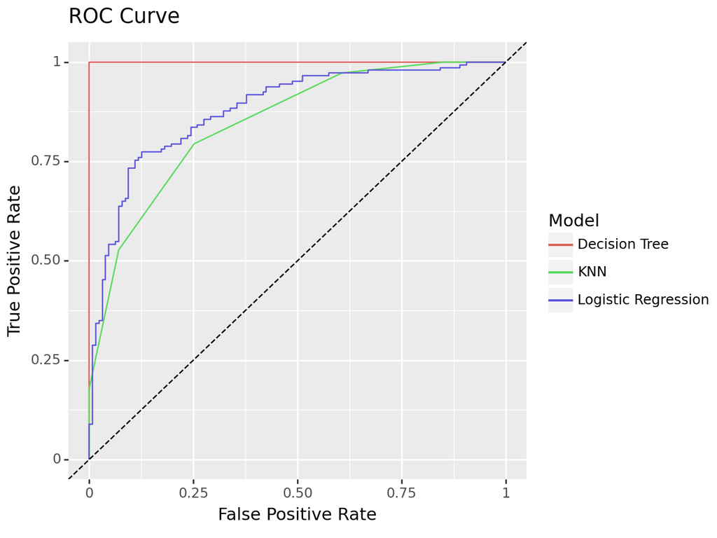

```python
from sklearn.metrics import roc_curve
from plotnine import ggplot, aes, geom_line, geom_abline, labs

# Define and fit the models
knn_pipeline = Pipeline([('dummify', ct), ('knc', KNeighborsClassifier(n_neighbors=5))])
log_reg_pipeline = Pipeline([('dummify', ct), ('lg', LogisticRegression())])
dt_pipeline = Pipeline([('dummify', ct), ('dt', DecisionTreeClassifier())])

knn_pipeline.fit(X, y)
log_reg_pipeline.fit(X, y)
dt_pipeline.fit(X, y)

# Calculate the ROC curve for each model
fpr_knn, tpr_knn, _ = roc_curve(y, knn_pipeline.predict_proba(X)[:, 1])
fpr_log_reg, tpr_log_reg, _ = roc_curve(y, log_reg_pipeline.predict_proba(X)[:, 1])
fpr_dt, tpr_dt, _ = roc_curve(y, dt_pipeline.predict_proba(X)[:, 1])

# Create a DataFrame for ggplot
df_knn = pd.DataFrame({'FPR': fpr_knn, 'TPR': tpr_knn, 'Model': 'KNN'})
df_log_reg = pd.DataFrame({'FPR': fpr_log_reg, 'TPR': tpr_log_reg, 'Model': 'Logistic Regression'})
df_dt = pd.DataFrame({'FPR': fpr_dt, 'TPR': tpr_dt, 'Model': 'Decision Tree'})
roc_df = pd.concat([df_knn, df_log_reg, df_dt])

# Plot the ROC curve using ggplot
plot = (
    ggplot(roc_df, aes(x='FPR', y='TPR', color='Model'))
    + geom_line()
    + geom_abline(linetype='dashed')
    + labs(title='ROC Curve', x='False Positive Rate', y='True Positive Rate')
)
print(plot)
```

## Part Two: Metrics

Consider the following metrics:

True Positive Rate or Recall or Sensitivity = Of the observations that are truly Class A, how many were predicted to be Class A?

Precision or Positive Predictive Value = Of all the observations classified as Class A, how many of them were truly from Class A?

True Negative Rate or Specificity or Negative Predictive Value = Of all the observations classified as NOT Class A, how many were truly NOT Class A?

Compute each of these metrics (cross-validated) for your three models (KNN, Logistic Regression, and Decision Tree) in Part One.

```python
from sklearn.metrics import make_scorer, confusion_matrix
from sklearn.model_selection import cross_val_score

#chat gpt assisted with function
def specificity_score(y_true, y_pred):
    tn, fp, _, _ = confusion_matrix(y_true, y_pred).ravel()
    specificity = tn / (tn+fp)
    return specificity

specificity_scorer = make_scorer(specificity_score)

metrics = ['precision', 'recall', specificity_scorer]

# chatgpt assisted with function
def compute_cross_val_scores(model, X, y, metrics):
    scores = {}
    for metric in metrics:
        if isinstance(metric, str):
            score_name = metric
        else:
            score_name = specificity_score.__name__
        scores[score_name] = cross_val_score(model, X, y, scoring=metric, cv=5)  # using 5-fold cross-validation
    return scores

knn_scores = compute_cross_val_scores(knn_pipeline, X, y, metrics)
log_reg_scores = compute_cross_val_scores(log_reg_pipeline, X, y, metrics)
dt_scores = compute_cross_val_scores(dt_pipeline, X, y, metrics)

print("KNN Scores:", knn_scores)
print("Logistic Regression Scores:", log_reg_scores)
print("Decision Tree Scores:", dt_scores)
```

[output not shown]

[output cut: 50 more lines]

[output not shown]

```
KNN Scores: {'precision': array([0.65384615, 0.65714286, 0.61290323, 0.65625   , 0.5625    ]), 'recall': array([0.56666667, 0.79310345, 0.65517241, 0.72413793, 0.62068966]), 'specificity_score': array([0.64      , 0.53846154, 0.53846154, 0.56      , 0.44      ])}
Logistic Regression Scores: {'precision': array([0.70967742, 0.80645161, 0.91304348, 0.77142857, 0.72727273]), 'recall': array([0.73333333, 0.86206897, 0.72413793, 0.93103448, 0.82758621]), 'specificity_score': array([0.64      , 0.76923077, 0.92307692, 0.68      , 0.64      ])}
Decision Tree Scores: {'precision': array([0.66666667, 0.75862069, 0.73913043, 0.75      , 0.71428571]), 'recall': array([0.66666667, 0.75862069, 0.62068966, 0.82758621, 0.72413793]), 'specificity_score': array([0.64      , 0.73076923, 0.69230769, 0.72      , 0.64      ])}
```

# Part Three: Discussion

Suppose you have been hired by a hospital to create classification models for heart attack risk.

The following questions give a possible scenario for why the hospital is interested in these models. For each one, discuss:

Which metric(s) you would use for model selection and why.

Which of your final models (Part One Q1-3) you would recommend to the hospital, and why.

What score you should expect for your chosen metric(s) using your chosen model to predict future observations.

### Q4

### The hospital is training a new batch of doctors, and they would like to compare the diagnoses of these doctors to the predictions given by the algorithm to measure the ability of new doctors to diagnose patients.

# Part Four: Validation

```python
ha_validation = pd.read_csv("https://www.dropbox.com/s/jkwqdiyx6o6oad0/heart_attack_validation.csv?dl=1")
```

KNN

```python
X = ha_validation.drop('output', axis = 1)
y = ha_validation['output']
```

```python
ypreds = my_pipeline.predict(X)
ypreds
```

```
array([1, 1, 1, 1, 1, 1, 0, 0, 1, 0, 0, 1, 1, 1, 1, 1, 0, 1, 1, 1, 1, 0,
       1, 1, 1, 0, 0, 0, 0, 0])
```

```python
accuracy = accuracy_score(y, ypreds)
accuracy
```

```
0.6666666666666666
```

```python
confusedmetric = confusion_matrix(y, ypreds)
confusedmetric
```

```
array([[ 6,  5],
       [ 5, 14]])
```

Logistic

```python
ypreds2 = my_pipeline2.predict(X)
ypreds2
```

```
array([1, 1, 0, 0, 1, 1, 1, 1, 1, 1, 1, 1, 1, 1, 0, 1, 1, 0, 0, 1, 1, 0,
       0, 0, 0, 0, 0, 0, 0, 0])
```

```python
accuracy = accuracy_score(y, ypreds2)
accuracy
```

```
0.7666666666666667
```

```python
confusedmetric = confusion_matrix(y, ypreds2)
confusedmetric
```

```
array([[ 9,  2],
       [ 5, 14]])
```

Decision Tree

```python
ypreds3 = my_pipeline3.predict(X)
ypreds3
```

```
array([1, 1, 0, 0, 1, 1, 1, 1, 1, 0, 0, 1, 1, 1, 1, 1, 1, 0, 0, 0, 1, 0,
       0, 1, 0, 0, 1, 1, 0, 1])
```

```python
accuracy = accuracy_score(y, ypreds3)
accuracy
```

```
0.6333333333333333
```

```python
confusedmetric = confusion_matrix(y, ypreds3)
confusedmetric
```

```
array([[ 6,  5],
       [ 6, 13]])
```

### Results

Based on the below output, logistic performed the best on the validation by a good margin. My original models were quite simplistic, but including all the variables did initally give the the best results. Additional model testing and tuning may be needed along with gridsearch to find the best outcome without overfitting to the training data set.

```python
knn_probs = my_pipeline.predict_proba(X)[:, 1]
knn_auc = roc_auc_score(y, knn_probs)
knn_precision = precision_score(y, ypreds)
knn_recall = recall_score(y, ypreds)

log_reg_probs = my_pipeline2.predict_proba(X)[:, 1]
log_reg_auc = roc_auc_score(y, log_reg_probs)
log_reg_precision = precision_score(y, ypreds2)
log_reg_recall = recall_score(y, ypreds2)

dt_probs = my_pipeline3.predict_proba(X)[:, 1] if hasattr(my_pipeline3, 'predict_proba') else None
dt_auc = roc_auc_score(y, dt_probs) if dt_probs is not None else 'N/A'
dt_precision = precision_score(y, ypreds3)
dt_recall = recall_score(y, ypreds3)

print("KNN: AUC = {}, Precision = {}, Recall = {}".format(knn_auc, knn_precision, knn_recall))
print("Logistic Regression: AUC = {}, Precision = {}, Recall = {}".format(log_reg_auc, log_reg_precision, log_reg_recall))
print("Decision Tree: AUC = {}, Precision = {}, Recall = {}".format(dt_auc, dt_precision, dt_recall))
```

```
KNN: AUC = 0.7272727272727274, Precision = 0.7368421052631579, Recall = 0.7368421052631579
Logistic Regression: AUC = 0.8803827751196172, Precision = 0.875, Recall = 0.7368421052631579
Decision Tree: AUC = 0.6148325358851674, Precision = 0.7222222222222222, Recall = 0.6842105263157895
```

# Part Five: Cohen’s Kappa

```python
from sklearn.metrics import cohen_kappa_score

kappa_knn = cohen_kappa_score(y, ypreds)
kappa_log_reg = cohen_kappa_score(y, ypreds2)
kappa_dt = cohen_kappa_score(y, ypreds3)

print("Cohen's Kappa for KNN:", kappa_knn)
print("Cohen's Kappa for Logistic Regression:", kappa_log_reg)
print("Cohen's Kappa for Decision Tree:", kappa_dt)
```

```
Cohen's Kappa for KNN: 0.2822966507177034
Cohen's Kappa for Logistic Regression: 0.5248868778280543
Cohen's Kappa for Decision Tree: 0.22535211267605626
```

As seen in the above output, the logistic model comes out ahead again by a wide margin. After doing additional research, I do like this model because it deals with the possibility that the prediction was due to due chance, or was the closest, rather than it being confident or sure of it’s prediction. It’s gives a better idea of it’s reliability for future data, instead of it’s reliance on previous data. One thing I couldn’t find is, how can it be used on non-categorical data? Is there something can comes close instead of using RMSE?